# Overhead with Multithreading

Benjamin Christoffersen

2019-03-04

## Introduction

The objective of this file is to highlight the performance when multithreading is used. The conclusions likely depend on both the hardware, operating system and compiler.

We will simulate and estimate a first order vector auto-regression model in this example using the particle filter and smoother. For details see this vignette which can also be found by calling `vignette("Particle_filtering", package = "dynamichazard")`. The models we are going to simulate from and estimate are of the form

$$\begin{split}
y_{it} &\sim g(\cdot\vert\eta_{it}) & \\
\vec{\eta}_t &= X_tR^+\vec{\alpha}_t + Z_t\vec{\beta} + \vec{o}_t \\
\vec{\alpha}_t &= F\vec{\alpha}_{t - 1} + R\vec{\epsilon}_t &
\quad \vec{\epsilon}_t \sim N(\vec{0}, Q) \\
& & \quad \vec{\alpha}_0 \sim N(\vec{a}_0, Q_0)
\end{split}, \qquad
\begin{array}{l} i = 1, \dots, n_t \\ t = 1, \dots, d \end{array}$$

where the $y_{it}$ is individual $i$’s indicator at time $t$ for whether he dies between time $(t - 1, t]$. The indicators, $y_{it}$, are binomial distributed with the complementary log-log link function conditional on knowing the log times at risk, $\vec{o}_1,\cdots,\vec{o}_d$, covariates, $X_t$ and $Z_t$, and latent states, $\vec{\alpha}_1,\dots,\vec{\alpha}_d$. The total survival time of individual $i$ is $T_i$ which is piecewise constant exponentially distributed conditional on knowing the latent states. Further, we set $Z_t = X_t$ so the states have a non-zero mean. The true values are

$$F = \begin{pmatrix}0.9 & 0 \\ 0 & 0.9 \end{pmatrix}, \quad
Q = \begin{pmatrix}0.33^2 & 0 \\ 0 & 0.33^2 \end{pmatrix}, \quad
R = I_2, \quad
\vec{\beta} = (-6.5, -2)^\top$$

where $I_2$ is the two-dimensional identity matrix and $\vec{a}_0$ and $Q_0$ are given by the invariant distribution. The unknown parameters to be estimated is everything but $Q_0$ and $R$ (since we fix $Q_0$ doing the estimation and we set $\vec{a}_0 = (0, 0)^\top$). This example is run on the git branch “devel” with ID “789b7e9”. The code can be found on the Github site for the package. All functions which assignments are not shown and are not in the `dynamichazard` package can be found on the Github site.

## Simulation

We start by simulating the data. Feel free to skip this part as the specifications are given above. First we assign the parameters for the simulation

```r
n_periods <- 300L

Fmat <- matrix(c(.9, 0, 0, .9), 2)
Rmat <- diag(1    , 2)
Qmat <- diag(.33^2, 2)
Q_0  <- get_Q_0(Qmat, Fmat)
beta <- c(-6.5, -2)
```

`get_Q_0` is a function to get the covariance matrix for the invariant distribution. Then we simulate and plot the latent states

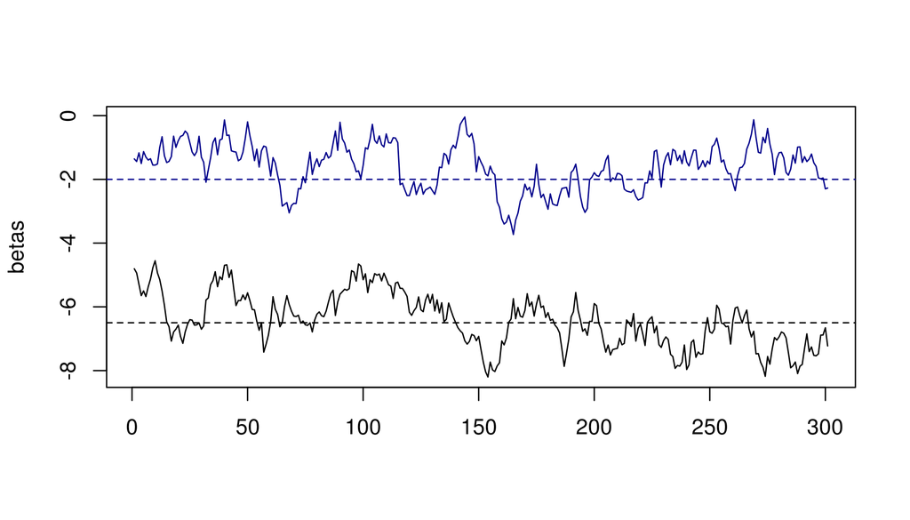

```r
set.seed(54432125)
betas <- matrix(nrow = n_periods + 1, ncol = 2)
betas[1, ] <- rnorm(2) %*% chol(Q_0)
for(i in 1:n_periods + 1)
  betas[i, ] <- Fmat %*% betas[i - 1, ] + drop(rnorm(2) %*% chol(Qmat))

betas <- t(t(betas) + beta)

# plot of latent variables
cols <- c("black", "darkblue")
matplot(betas, type = "l", lty = 1, col = cols)
for(i in 1:2)
  abline(h = beta[i], lty = 2, col = cols[i])
```

We simulate the observations as follows

```r
# assign function to simulate observations
get_obs <- function(n_obs){
  set.seed(37723679)
  df <- replicate(n_obs, {
    # left-censoring
    tstart <- max(0L, sample.int((n_periods - 1L) * 2L, 1) - n_periods + 1L)

    # covariates
    x <- runif(1, -1, 1)
    covars <- c(1, x)

    # outcome (stop time and event indicator)
    y <- FALSE
    for(tstop in (tstart + 1L):n_periods){
      fail_time <- rexp(1) / exp(covars %*% betas[tstop + 1L, ])
      if(fail_time <= 1){
        y <- TRUE
        tstop <- tstop - 1L + fail_time
        break
      }
    }

    c(tstart = tstart, tstop = tstop, x = x, y = y)
  })
  df <- data.frame(t(df))
}

# use function
df <- get_obs(3000L)
head(df, 10)
```

```
##    tstart  tstop        x y
## 1      42 300.00  0.60105 0
## 2       0 300.00  0.78599 0
## 3       0 300.00  0.80020 0
## 4       0 300.00  0.75193 0
## 5       0 300.00  0.77171 0
## 6       0  30.15  0.48807 1
## 7     255 300.00 -0.02113 0
## 8     223 300.00  0.45553 0
## 9     174 300.00 -0.77043 0
## 10      0 300.00  0.38432 0
```

We left-censor the observations since we otherwise may end up with a low number of observations towards the end.

## Particle filter and smoother

We use the generalized two-filter smoother from Fearnhead, Wyncoll, and Tawn (2010)

```r
library(dynamichazard)
```

```r
func <- function(N_fw_n_bw, N_smooth, N_first){
  lapply(1:6, function(n_threads){
    set.seed(30520116)
    suppressWarnings(ti <- system.time(pf_Fear <- PF_EM(
      Surv(tstart, tstop, y) ~ x + ddFixed(x) + ddFixed_intercept(TRUE), df,
      Q_0 = diag(1, 2), Q = diag(1, 2), Fmat = matrix(c(.1, 0, 0, .1), 2),
      by = 1, type = "VAR", model = "exponential", max_T = n_periods,
      control = PF_control(
        N_fw_n_bw = N_fw_n_bw, N_smooth = N_smooth, N_first = N_first,
        method = "AUX_normal_approx_w_cloud_mean",
        n_max = 1, # Just take one EM-iteration
        smoother = "Fearnhead_O_N",
        Q_tilde = diag(.3^2, 2), n_threads = n_threads))))
    list(ti = ti, fit = pf_Fear, n_threads = n_threads)
  })
}
```

```r
out <- func(200L, 500L, 2000L)
```

We assign a function to check the results

```
## All estimates match
```

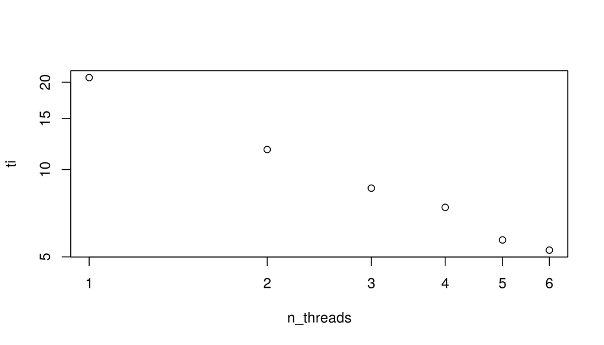

```
## Ols estimates are
##    (Intercept) log(n_threads)
##         3.0167        -0.7663
```

```r
show_res <- function(out){
  do_check <- c("fixed_effects", "Q", "F")
  if(all(sapply(
    out[-1L], function(target)
      isTRUE(all.equal(target$fit[do_check], out[[1]]$fit[do_check])))))
    cat("All estimates match\n")

  # plot log time versus log number of threads
  ti        <- sapply(out, "[[", "ti")["elapsed", ]
  n_threads <- sapply(out, "[[", "n_threads")
  plot(ti ~ n_threads, log = "xy")

  cat("Ols estimates are\n")
  print(coef(lm(log(ti) ~ log(n_threads))))
}
show_res(out)
```

Increasing the number of particles we use changes the results

```r
out <- func(5000L, 5000L, 10000L)
```

```r
show_res(out)
```

```
## All estimates match
```

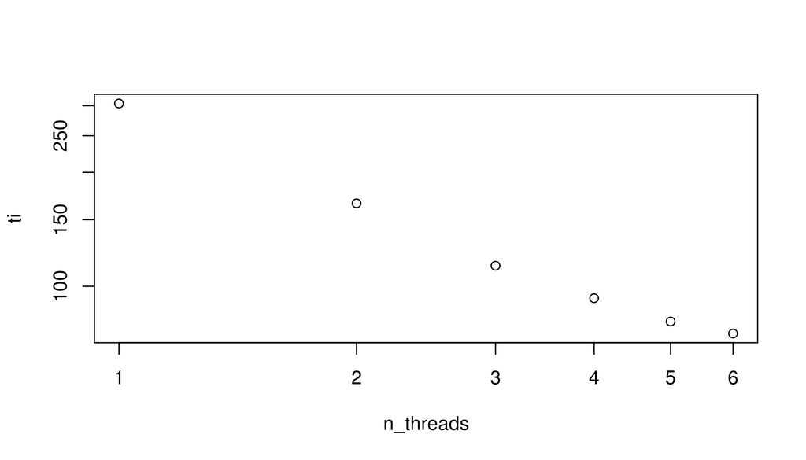

```
## Ols estimates are
##    (Intercept) log(n_threads)
##         5.6757        -0.7987
```

Similar changes apply for for larger data sets

```r
df <- get_obs(10000L)
out <- func(200L, 500L, 2000L)
```

```r
show_res(out)
```

```
## All estimates match
```

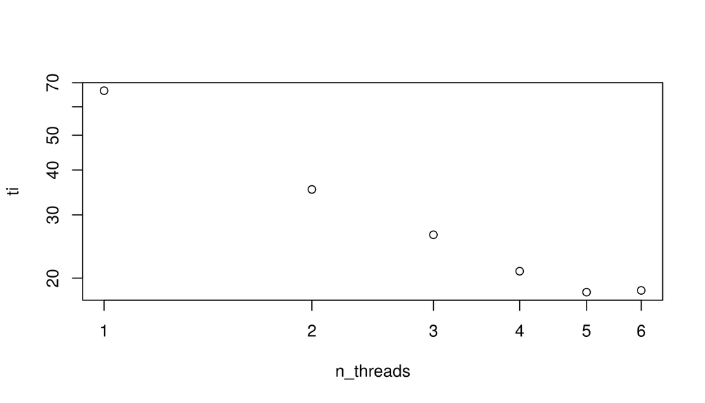

```
## Ols estimates are
##    (Intercept) log(n_threads)
##         4.1329        -0.7446
```

```r
parallel::detectCores(logical = FALSE)
```

```
## [1] 12
```

## References

Fearnhead, Paul, David Wyncoll, and Jonathan Tawn. 2010. “A Sequential Smoothing Algorithm with Linear Computational Cost.” *Biometrika* 97 (2). [Oxford University Press, Biometrika Trust]: 447–64. http://www.jstor.org/stable/25734097.